# Final Assignment

Candidate Number: 35031

10 January 2024

## GitHub

The GitHub repository for **this assignment** can be found [here](https://github.com/emmi3105/472_final).[^1]

## Research question:

“*Rolling Stone* Magazine ranked their 100 greatest musical artists of all time. At the end of 2023, how has their music endured? Are there any features or characteristics that seem to explain enduring engagement?

## 1. Introduction

We approached the question in two steps. Firstly, we measured the endurance of the Rolling Stone’s Top 100 (RS-T100) by calculating `Endurance Scores`, which we compared to endurance of the most popular artists of 2023. Secondly, we analysed correlations between endurance, latest album release dates, being on tour, and album certifications.

## 2. Data

### Rolling Stone Data

Firstly, we extracted the names of the [Rolling Stone’s 100 Greatest Artists](https://www.rollingstone.com/music/music-lists/100-greatest-artists-147446/) (RS-T100).

### Spotify API

Using the [Spotify Web API](https://developer.spotify.com/documentation/web-api), we retrieved additional data on the on the RS-T100, including the Spotify artist ID, Followers, Popularity, and the date of the latest album release. The same variables were extracted for the artists in the playlist [`Top Artists of 2023 USA`](https://open.spotify.com/playlist/37i9dQZF1DX4dwwIoKH0j7) (Spotify-T50). Focusing on the US market provides a relevant comparison to RS-T100, given the Rolling Stone’s US origin and the prominence of the US on Spotify. Manual corrections were made for inaccuracies in the Spotify artist ID extraction for “Parliament Funkadelic”.

### LastFM API

Utilising the [LastFM API](https://www.last.fm/de/api), we additionally gathered the Playcount, Listeners, and on-tour status for RS-T100 and Spotify-T50. Furthermore, we extracted all of the previously mentioned variables for the top 50 artists as ranked on LastFM (LastFM-T50).

### RIAA Data (Wikipedia)

To explore potential correlations between awards and artist popularity, we gathered details on Recording Industry Association of America (RIAA) certifications. These certifications are grounded in album sales across retail and ancillary markets, sourced from [Wikipedia](https://en.wikipedia.org/wiki/List_of_highest-certified_music_artists_in_the_United_States). The previously listed data were collected for the RIAA Top 100 artists (RIAA-T100).[^2]

### Data Storage

All data were organised into tables, which were stored in a relational database using `Spotify_Artist_ID` as the primary key.

1. Rolling Stone’s: Top 100 Artists (2010)

```
## The table top_hundred_artists_df exists and has the following dimensions:
## Number of rows: 100
## Number of columns: 11
## Column names: Spotify_Artist_ID, Artist_Name, Ranking, Article_Text, Followers, Genres, Popularity, Latest_Album_Release, Listeners_LastFM, Playcount_LastFM, On_Tour
```

2. Spotify: Top 50 Artists of 2023

```
## The table top_artists_2023_USA_df exists and has the following dimensions:
## Number of rows: 50
## Number of columns: 8
## Column names: Spotify_Artist_ID, Artist_Name, Followers, Popularity, Latest_Album_Release, Listeners_LastFM, Playcount_LastFM, On_Tour
```

3. LastFM: Top 50 Artists Charts

```
## The table charts_artists_df exists and has the following dimensions:
## Number of rows: 50
## Number of columns: 9
## Column names: Spotify_Artist_ID, Artist_Name, Playcount, Listeners, Top_Hundred, Followers, Popularity, On_Tour, Latest_Album_Release
```

4. RIAA: Highest-certified Music Artists in the US based on Certifications of Albums

```
## The table certified_albums_df exists and has the following dimensions:
## Number of rows: 102
## Number of columns: 11
## Column names: Rank, Million_Units, Artist_Name, Nat., Active, Spotify_Artist_ID, Top_Hundred, Followers, Popularity, Listeners_LastFM, Playcount_LastFM
```

### Variables of Interest

The table below summarises the variables relevant to our analysis.

| Variable | Explanation | Source |
| --- | --- | --- |
| Artist_Name | Name of the artist | Rolling Stone/Spotify/Last FM/RIAA |
| Spotify_Artist_ID | Artist ID | Spotify |
| Ranking | RS-T100 ranking | Rolling Stone |
| Followers | Followers on Spotify | Spotify |
| Popularity | Popularity on Spotify (1-100) | Spotify |
| Latest_Album_Release | Date of the most recent album release | Spotify |
| Listeners_LastFM | Listeners on LastFM | Last FM |
| Playcount_LastFM | Number of times a song has been played on LastFM | Last FM |
| On_Tour | Binary indicator: 1 if the artist is on tour, 0 otherwise | Last FM |
| Million_Units | RIAA album units in millions: 1,500 streams = 1 album unit and 10 track sales = 1 album unit | RIAA |
| Top_Hundred | Binary indicator: 1 if the artist appears in the RS-T100, 0 otherwise | Own calculation |

## 3. Analysis

### A. Are the Rolling Stone’s Top 100 still relevant in 2023?

We calculate two *Endurance Scores* for the RS-T100, Spotify-T50, LastFM-T50, and RIAA-T100:

$Spotify\_Endurance = Popularity * Followers$

$LastFM\_Endurance = Playcount\_LastFM * Listeners\_LastFM$

Next, we scale the endurance scores, setting the highest score, which is Taylor Swift on both, Spotify and LastFM, to 100% and a score of 0 to 0%.[^3]

#### On a scale of 1 to Taylor Swift …?

Firstly, we investigate how the `Spotify_Endurance` and the `LastFM_Endurance` are correlated for the RS-T100, LastFM-T50 and Spotify-T50.

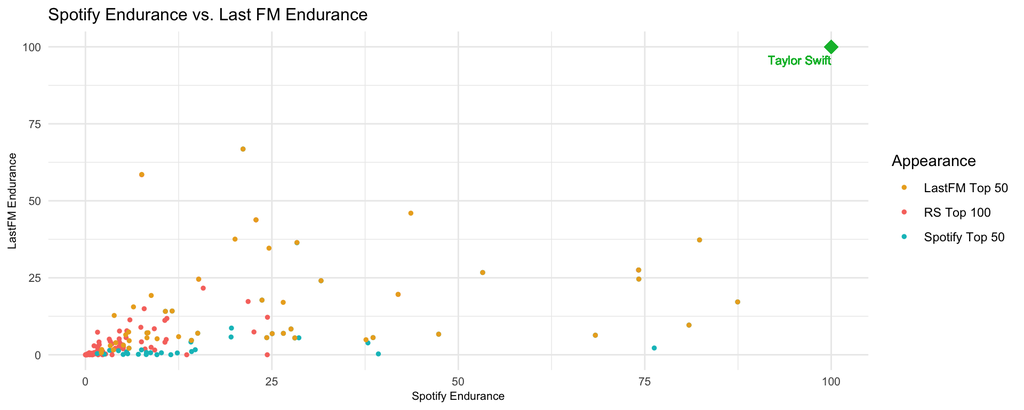

Secondly, we examine potential differences in the distribution of endurance across the three groups of artists.

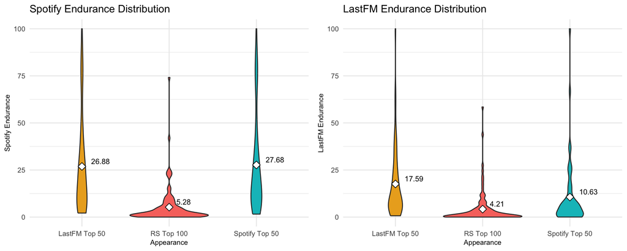

#### Intersections

The RS-T100, which exhibit outlier values for endurance scores, may not be confined solely to the Rolling Stones ranking, but could also be found in the Spotify-T50 and LastFM-T50. Therefore, we look at the intersections of the RS-T100, Spotify-T50 and LastFM-T50.

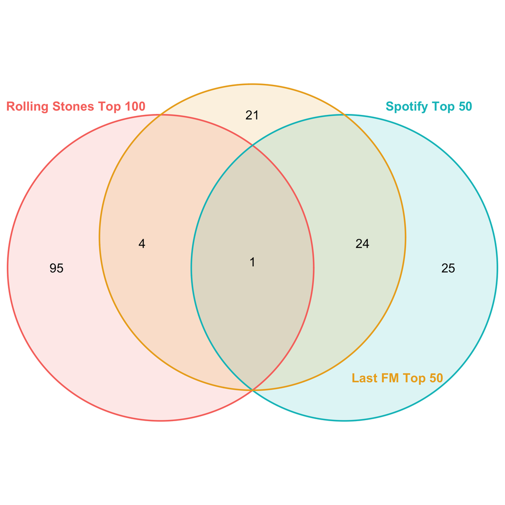

Intersection of Rolling Stones Top 100, Spotify Top 50, LastFM Top 50

The diagram above shows that there indeed are artists that appear in the RS-T100 as well as the Spotify- or LastFM-T50. In the scatter plot below, we examine whether these artists exhibit higher endurance scores compared to artists that exclusively are RS-T100.

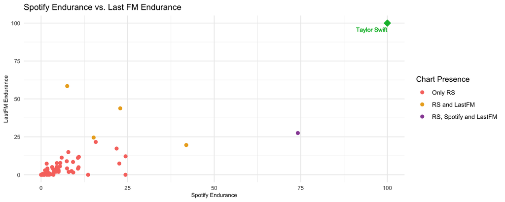

**Results**: As expected, the RS-T100 that display the highest values for endurance are also in the Spotify- and LastFM-T50. We can confirm that these artists still endure in 2023. Yet overall, endurance of the RS-T100 is relatively low.

### B. What explains endurance?

#### i. Latest Album Release vs. Endurance

**Results**: As visualised below, we find that recent album releases positively correlate with higher endurance scores for all artists.

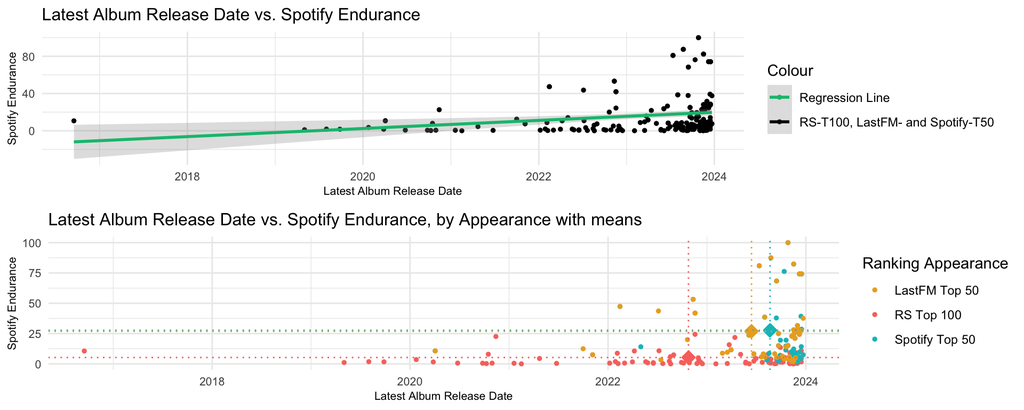

#### ii. On Tour

**Results**: We find that artists that are currently on tour have higher average endurance scores, which especially holds for the Spotify- and LastFM-T50. Further research could investigate the causality of being on tour and endurance using statistical tests.

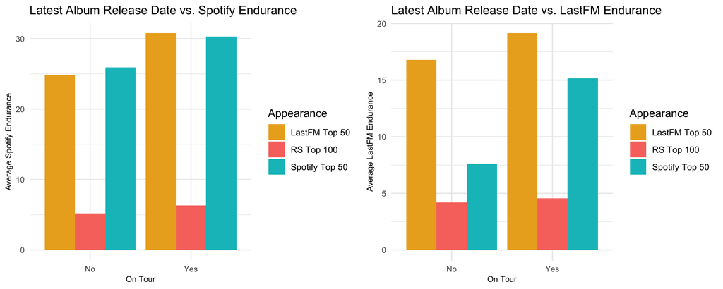

#### iii. RIAA Certifications vs. Endurance

**Result**: We do not find a strong correlation between endurance and RIAA certification units, as plotted below.

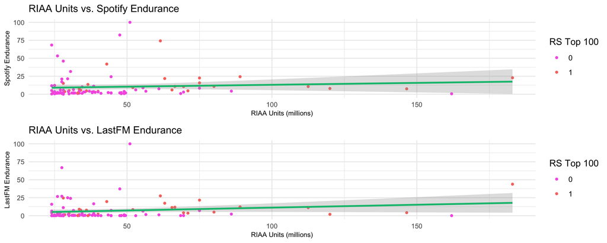

However, as seen in the diagram below, we noticed that a quarter of the RS-T100 are also within the RIAA-T100. Potentially, the selection of the RS-T100 artists was inspired by historical certifications rather than endurance in 2023.

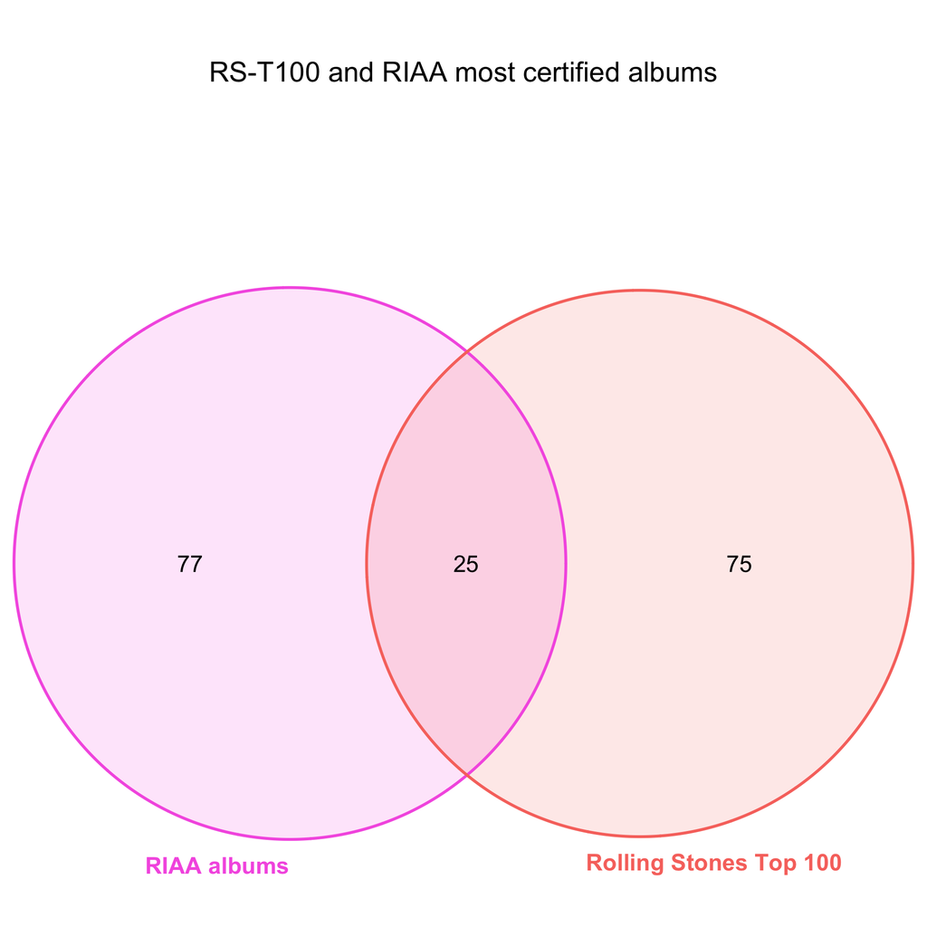

### C. Discussion

In summary, our analysis reveals that most RS-T100 artists trail behind the popularity of the Spotify- and LastFM-T50. Yet, some RS-T100 still reach high popularity scores today. These artists also tend to appear in the Spotify- and LastFM-T50. Investigating factors influencing endurance, we found that recent album releases and being on tour positively correlate with endurance, while receiving numerous RIAA certifications has little association with endurance. Further research could explore the causality of the relationships we found, for instance, using an instrumental variable regression. Last but not least, we can confirm that the craze around Taylor Swift is unparalleled.[^4]

## Data

### Required Data

[1] [Rolling Stone’s 100 Greatest Artists, 2010](https://www.rollingstone.com/music/music-lists/100-greatest-artists-147446/)

[2] [Spotify Web API](https://developer.spotify.com/documentation/web-api)

### Additional Data

[3] [LastFM API](https://www.last.fm/de/api)

[4] [RIAA Album Certifications (from Wikipedia)](https://en.wikipedia.org/wiki/List_of_highest-certified_music_artists_in_the_United_States).

## Appendix: All code in this assignment

```r
#####################################
# SETUP

knitr::opts_chunk$set(echo = FALSE)

library(tidyverse)
library(RSelenium)
library(netstat)
library(DBI)
library(RSQLite)
library(purrr)
library(httr)
library(base64enc)
library(jsonlite)
library(rvest)
library(plotly)
library(VennDiagram)
library(grid)
library(png)
library(cowplot)
library(knitr)

#####################################
# Create a relational database

db <- dbConnect(RSQLite::SQLite(), "data/spotify.sqlite")

# Function that checks whether a table exists in the relational database
check_table <- function(db, a_table){

  # Check if the "a_table" exists
  if (a_table %in% dbListTables(db)) {

    # Get the row count
    query <- paste("SELECT COUNT(*) FROM", a_table)
    row_count <- dbGetQuery(db, query)[1, 1]

    # Get the column names
    column_names <- as.character(dbListFields(db, a_table))

    # Get the column count
    column_count <- length(unlist(column_names))

    # Print out dimensions and column names
    formatted_string <- sprintf("The table %s exists and has the following dimensions: \nNumber of rows: %s \nNumber of columns: %s", a_table, row_count, column_count)
    column_answer <- sprintf("Column names: %s", paste(column_names, collapse = ", "))

    return(cat(formatted_string, column_answer, sep = "\n"))

  } else {
    # If "a_table" does not exist, return this statement:
    return(cat("The table does not exist."))
  }
}

#####################################
# Extract Rolling Stones data

# Launch the driver and browser
invisible(capture.output({
  rD <- rsDriver(browser=c("firefox"), port = free_port(random = TRUE), chromever = NULL)
  driver <- rD$client
}))

# Navigate to the website
url <- "https://www.rollingstone.com/music/music-lists/100-greatest-artists-147446/"
driver$navigate(url)

# Reject the privacy policies
reject_button <- driver$findElement(using = "xpath",
                                    value = '//*[@id="onetrust-reject-all-handler"]')
# Click on the button:
reject_button$clickElement()

# Create a data frame that will later hold the top 100 artists
top_hundred_artists_df <- data.frame(
  Artist_Name = character(0),
  Ranking = numeric(0),
  Article_Text = character(0),
  stringsAsFactors = FALSE
)

# Add 100 empty rows
top_hundred_artists_df <- top_hundred_artists_df[rep(NA, 100), ]

# Click the load more button
load_more <- function(){
  # Load more button
  load_more_button <- driver$findElement(using = "xpath",
                                      value = '/html/body/div[5]/main/div[2]/div[1]/div/article/div[3]/div[2]/div[2]/a')
  # Click on the button:
  load_more_button$clickElement()
}

# Click the load previous button
load_previous <- function(){
  # Load previous button
  load_previous_button <- driver$findElement(using = "xpath",
                                         value = '/html/body/div[5]/main/div[2]/div[1]/div/article/div[3]/div[2]/div[1]')
  # Click on the button:
  load_previous_button$clickElement()
}

# Extract the rankings
extract_rank <- function(){

  artist_rank_elements <- driver$findElements(using = "class name", value = "c-gallery-vertical-album__number")

  artist_ranks <- sapply(artist_rank_elements, function(element) element$getElementText()[[1]])

  return(artist_ranks)
}

# Extract the artist names
extract_artist_names <- function(){

  artist_name_elements <- driver$findElements(using = "class name", value = "c-gallery-vertical-album__title")

  artist_names <- sapply(artist_name_elements, function(element) element$getElementText()[[1]])

  return(artist_names)
}

# Extract the article text
extract_article_text <- function(){

  article_text_elements <- driver$findElements(using = "class name", value = "c-gallery-vertical-album__description")

  article_text <- sapply(article_text_elements, function(element) element$getElementText()[[1]])

  return(article_text)
}

# Scrape the data
scrape_artist_rankings <- function(){
  # Get the first 50 artists
  top_hundred_artists_df$Ranking[1:50] <- extract_rank()
  top_hundred_artists_df$Artist_Name[1:50] <- extract_artist_names()
  top_hundred_artists_df$Article_Text[1:50] <- extract_article_text()

  # Click the load more button
  load_more()
  Sys.sleep(2)

  # Get the last 50 artists
  top_hundred_artists_df$Ranking[51:100] <- extract_rank()
  top_hundred_artists_df$Artist_Name[51:100] <- extract_artist_names()
  top_hundred_artists_df$Article_Text[51:100] <- extract_article_text()

  return(top_hundred_artists_df)
}

# Call the artist ranking web scraping function
top_hundred_artists_df <- scrape_artist_rankings()

# Save the data frame as a global variable
assign("top_hundred_artists_df", top_hundred_artists_df, envir = .GlobalEnv)

# Save the data frame as an RData file in the current working directory
save(top_hundred_artists_df, file = "data/top_hundred_artists_data.RData")

# Load the data from the RData file
load("data/top_hundred_artists_data.RData")

# Make a copy of the data frame
top_hundred_artists <- data.frame(top_hundred_artists_df)

# Close the RSelenium processes:
driver$close()
# Close the associated Java processes
system("taskkill /im java.exe /f", intern=FALSE, ignore.stdout=FALSE)

#####################################
# Extract Spotify Web API data

readRenviron("../../Documents/R_Environs/spotify_api.env")
client_id <- Sys.getenv("CLIENT_ID")
client_secret <- Sys.getenv("CLIENT_SECRET")

# Create a base64-encoded string of the client ID and client secret
credentials <- paste0(client_id, ':', client_secret)
base64_credentials <- base64enc::base64encode(charToRaw(credentials))

# Set up the authentication request
auth_response <- httr::POST(
  'https://accounts.spotify.com/api/token',
  add_headers(
    Authorization = paste0('Basic ', base64_credentials),
    'Content-Type' = 'application/x-www-form-urlencoded'
  ),
  body = list(grant_type = 'client_credentials'),
  encode = 'form'
)

# Check for HTTP errors
if (http_error(auth_response)) {
  print(status_code(auth_response))
  print(content(auth_response, "text"))
} else {
  # Extract the access token from the response
  access_token <- httr::content(auth_response)$access_token
}
```

```r
# 1) Get the artist ID given the artist name

get_artist_id <- function(artist_name) {
  # Define the Spotify API endpoint for searching an artist
  search_url <- 'https://api.spotify.com/v1/search'

  # Set up the request with the access token
  search_response <- GET(
    search_url,
    query = list(q = artist_name, type = 'artist'),
    add_headers(Authorization = paste0('Bearer ', access_token))
  )

  # Extract the artist ID from the response
  search_results <- content(search_response, "parsed")

  # Check if any results were returned
  if (length(search_results$artists$items) > 0) {
    artist_id <- search_results$artists$items[[1]]$id
    return(artist_id)
  } else {
    # Return NA or any other value to indicate no match
    return(NA)
  }
}

# Apply the function to the entire "Artist_Name" column in the data frame
top_hundred_artists$Spotify_Artist_ID <- sapply(top_hundred_artists$Artist_Name, get_artist_id)

# Replace the ID for Parliament and Funcadelic: 6XswoC68grx55in1WQnJ7E
top_hundred_artists <- top_hundred_artists %>%
  mutate(Spotify_Artist_ID = ifelse(Artist_Name == "Parliament and Funkadelic", "6XswoC68grx55in1WQnJ7E", Spotify_Artist_ID))

# 2) Get the artist info given the artist ID

get_artist_info <- function(artist_id){
  # Define the Spotify API endpoint for getting information about an artist
  artist_url <- paste0('https://api.spotify.com/v1/artists/', artist_id)

  # Set up the request with the access token
  artist_response <- GET(artist_url, add_headers(Authorization = paste0('Bearer ', access_token)))

  # Extract the artist information from the response
  artist_info <- content(artist_response)

  followers <- artist_info$followers$total[1]
  genres <- artist_info$genres[1]
  popularity <- artist_info$popularity

  # Create a list with the extracted information
  artist_data <- list(followers = followers, genres = genres, popularity = popularity)

  return(artist_data)
}

# Apply the function to the entire "Artist_Name" column in the data frame
result <- lapply(top_hundred_artists$Spotify_Artist_ID, get_artist_info)

# Extract individual elements
top_hundred_artists$Followers <- sapply(result, function(x) x$followers)
top_hundred_artists$Genres <- sapply(result, function(x) x$genres)
top_hundred_artists$Popularity <- sapply(result, function(x) x$popularity)


# Remove the row names
top_hundred_artists <- data.frame(top_hundred_artists, row.names = NULL)
# Transform the "Genres" column into type character
top_hundred_artists$Genres <- sapply(top_hundred_artists$Genres, function(x) paste(x, collapse = ","))

# 3) Get the release date of the latest album

# Create an empty data frame for the top tracks
album_data <- data.frame(
  Spotify_Artist_ID = character(0),
  Artist_Name = character(0),
  Spotify_Album_ID = character(0),
  Album_Name = character(0),
  Album_Release_Date = character(0),
  Number_of_Tracks = numeric(0),
  stringsAsFactors = FALSE
)

get_album_data <- function(the_artist_id){

  album_url <- paste0('https://api.spotify.com/v1/artists/', the_artist_id, '/albums')
  # Set up the request with the access token
  album_response <- GET(album_url,
                        add_headers(Authorization = paste0('Bearer ', access_token)))

  album_info <- content(album_response)

  return(album_info)
}

# Function that gets the album data given the artist ID and using the function get_album_data
get_albums <- function(the_artist_id) {

  # Get the data given the artist id
  albums <- get_album_data(the_artist_id)

  # Loop through the top tracks for each artist
  if (!is.null(albums$items) && length(albums$items) > 0) {
    # Enter the loop
    for (i in seq(length(albums$items))) {

      # Check and extract values, appending NA if a value is missing
      album_data <- rbind(album_data, data.frame(
        Spotify_Artist_ID = ifelse(!is.null(the_artist_id), the_artist_id, NA),
        Artist_Name = ifelse(!is.null(albums$items[[i]]$artists[[1]]$name), albums$items[[i]]$artists[[1]]$name, NA),
        Spotify_Album_ID = ifelse(!is.null(albums$items[[i]]$id), albums$items[[i]]$id, NA),
        Album_Name = ifelse(!is.null(albums$items[[i]]$name), albums$items[[i]]$name, NA),
        Album_Release_Date = ifelse(!is.null(albums$items[[i]]$release_date), albums$items[[i]]$release_date, NA),
        Number_of_Tracks = ifelse(!is.null(albums$items[[i]]$total_tracks), albums$items[[i]]$total_tracks, NA)
        ))
    }
  } else {
    album_data <- rbind(album_data, data.frame(
      Spotify_Artist_ID = the_artist_id,
      Artist_Name = NA,
      Spotify_Album_ID = NA,
      Album_Name = NA,
      Album_Release_Date = NA,
      Number_of_Tracks = NA))
  }

  return(album_data)
}

result_list <- lapply(top_hundred_artists$Spotify_Artist_ID, get_albums)
album_data <- do.call(rbind, result_list)


album_data <- album_data %>%
  mutate(
    is_full_date = grepl("\\d{4}-\\d{2}-\\d{2}", Album_Release_Date),
    Album_Release_Date = case_when(
      is_full_date ~ as.Date(Album_Release_Date, format = "%Y-%m-%d"),
      TRUE ~ as.Date(paste0(Album_Release_Date, "-01-01"), format = "%Y-%m-%d")
    )
  )

# Remove the temporary column
album_data$is_full_date <- NULL

# Group by Artist_ID and find the latest album release date
Latest_Album_Release <- album_data %>%
  group_by(Spotify_Artist_ID) %>%
  summarize(Latest_Album_Release = max(Album_Release_Date, na.rm = TRUE))

# Merge the result back into top_hundred_artists
top_hundred_artists <- merge(top_hundred_artists, Latest_Album_Release, by = "Spotify_Artist_ID", all.x = TRUE)

top_hundred_artists$Latest_Album_Release <- as.character(top_hundred_artists$Latest_Album_Release)

# 4) Get the Spotify playlist "Top Artists of 2023, USA"

# Get a playlist
get_playlist <- function(playlist_id){

  # Spotify API endpoint for getting playlist details
  endpoint <- paste0('https://api.spotify.com/v1/playlists/', playlist_id)

  # Set up the request headers with the access token
  headers <- c('Authorization' = paste0('Bearer ', access_token))
```

```r
  # Make the GET request
  playlist_response <- GET(endpoint, add_headers(headers))
  playlist_data <- content(playlist_response, 'parsed')

  return(playlist_data)
}

# Function that gets the playlist info given the playlist id
get_playlist_info <- function(playlist_id, a_dataframe) {

  # Get the playlist data given the playlist id
  dt <- get_playlist(playlist_id)

  # Loop to append values
  for (i in seq(length(dt$tracks$items))) {
    # Append the values to the dataframe
    a_dataframe <- rbind(a_dataframe, data.frame(Playlist_Name = dt$name,
                                                 Playlist_ID = dt$id,
                                                 Playlist_Description = dt$description,
                                                 Track_Name = dt$tracks$items[[i]]$track$name,
                                                 Artist_Name = dt$tracks$items[[i]]$track$artists[[1]]$name,
                                                 Spotify_Track_ID = dt$tracks$items[[i]]$track$id,
                                                 Track_Duration = dt$tracks$items[[i]]$track$duration_ms,
                                                 Track_Popularity = dt$tracks$items[[i]]$track$popularity,
                                                 Album_Release_Date = dt$tracks$items[[i]]$track$album$release_date
                                                 ))
  }

  # Return the resulting dataframe
  return(a_dataframe)
}

# Create an empty dataframe
top_artists_2023_USA <- data.frame(
  Playlist_Name = character(0),
  Playlist_ID = character(0),
  Playlist_Description = character(0),
  Track_Name = character(0),
  Artist_Name = character(0),
  Spotify_Track_ID = character(0),
  Track_Duration = numeric(0),
  Track_Popularity = numeric(0),
  Album_Release_Date = character(0),
  stringsAsFactors = FALSE
)

# Get the Playlist Info
top_artists_USA_id <- "37i9dQZF1DX4dwwIoKH0j7"
top_artists_2023_USA <- get_playlist_info(top_artists_USA_id, top_artists_2023_USA)

# Create a dataframe for the artists on the Top Artists 2023 USA Playlist
top_artists_2023 <- data.frame(
  Artist_Name = top_artists_2023_USA$Artist_Name,
  stringsAsFactors = FALSE
)

# Get the artist ID
top_artists_2023$Spotify_Artist_ID <- lapply(top_artists_2023$Artist_Name, get_artist_id)

# Get Artist Info
result <- lapply(top_artists_2023$Spotify_Artist_ID, get_artist_info)

# Extract individual elements: Popularity and Followers
top_artists_2023$Followers <- sapply(result, function(x) x$followers)
top_artists_2023$Popularity <- sapply(result, function(x) x$popularity)

# Remove the row names
top_artists_2023 <- data.frame(top_artists_2023, row.names = NULL)

# Convert list columns to character
top_artists_2023$Spotify_Artist_ID <- as.character(top_artists_2023$Spotify_Artist_ID)

# Latest Album Release Date

album_data <- data.frame(
  Spotify_Artist_ID = character(0),
  Artist_Name = character(0),
  Spotify_Album_ID = character(0),
  Album_Name = character(0),
  Album_Release_Date = character(0),
  Number_of_Tracks = numeric(0),
  stringsAsFactors = FALSE
)

result_list <- lapply(top_artists_2023$Spotify_Artist_ID, get_albums)
album_data <- do.call(rbind, result_list)


album_data <- album_data %>%
  mutate(
    is_full_date = grepl("\\d{4}-\\d{2}-\\d{2}", Album_Release_Date),
    Album_Release_Date = case_when(
      is_full_date ~ as.Date(Album_Release_Date, format = "%Y-%m-%d"),
      TRUE ~ as.Date(paste0(Album_Release_Date, "-01-01"), format = "%Y-%m-%d")
    )
  )

# Remove the temporary column
album_data$is_full_date <- NULL

# Group by Artist_ID and find the latest album release date
Latest_Album_Release <- album_data %>%
  group_by(Spotify_Artist_ID) %>%
  summarize(Latest_Album_Release = max(Album_Release_Date, na.rm = TRUE))

# Merge the result back into top_artists_2023
top_artists_2023 <- merge(top_artists_2023, Latest_Album_Release, by = "Spotify_Artist_ID", all.x = TRUE)

top_artists_2023$Latest_Album_Release <- as.character(top_artists_2023$Latest_Album_Release)

#####################################
# Extract RIAA data from Wikipedia

get_wikipedia_tables <- function(url){
  # Storing the URL's HTML code
  html_content <- read_html(url)

  # Extracting all tables in the document
  tab <- html_table(html_content, fill = TRUE)

  return(tab)
}

url <- "https://en.wikipedia.org/wiki/List_of_highest-certified_music_artists_in_the_United_States"
tab <- get_wikipedia_tables(url)

certified_albums_data <- as_tibble(tab[[1]][, 1:5])

# Save the tables as global variables
assign("certified_albums_data", certified_albums_data, envir = .GlobalEnv)

# Save the global variables to an RData files
save(certified_albums_data, file = "data/certified_albums_data.RData")

# Load global variables
load("data/certified_albums_data.RData")

# Copy the scraped table to avoid modifying the original data
certified_albums <- certified_albums_data


certified_albums <- certified_albums %>%
  rename(Artist_Name = Name,
         Million_Units = `Units(millions)`) %>%
  mutate(Spotify_Artist_ID = ifelse(Artist_Name %in% top_hundred_artists$Artist_Name,
                            top_hundred_artists$Spotify_Artist_ID[match(Artist_Name, top_hundred_artists$Artist_Name)],
                            NA)) %>%
  mutate(Top_Hundred = ifelse(!is.na(Spotify_Artist_ID), 1, 0))

# Get all artist IDs
certified_albums$Spotify_Artist_ID <- sapply(certified_albums$Artist_Name, get_artist_id)

# Get Spotify Popularity and Followers
result <- lapply(certified_albums$Spotify_Artist_ID, get_artist_info)
certified_albums$Followers <- sapply(result, function(x) x$followers)
certified_albums$Popularity <- sapply(result, function(x) x$popularity)

#####################################
# Extract LastFM API data

# Set up the API Key and endpoint
readRenviron("../../Documents/R_Environs/lastfm_api.env")
lastfm_apikey <- Sys.getenv("KEY")
lastfm_endpoint <- "http://ws.audioscrobbler.com/2.0/"

# Function that gets the chart data
get_charts <- function(a_method){
  # Set parameters for the request
  params <- list(
    method = a_method,
    api_key = lastfm_apikey,
    format = "json"
  )
```

```r
  # Make the GET request
  response <- GET(lastfm_endpoint, query = params)
  content <- content(response, "parsed")

  return(content)
}

# Define the method
method_artists = "chart.getTopArtists"

# Create an empty data frame
charts_artists_data <- data.frame(
  Artist_Name = character(0),
  Playcount = numeric(0),
  Listeners = numeric(0),
  stringsAsFactors = FALSE
)

get_charts_info_artists <- function(a_method, dt_frame) {

  # Get the playlist data given the playlist id
  dt <- get_charts(a_method)

  # Loop to append values
  for (i in seq(length(dt$artists$artist))) {
    # Append the values to the dataframe
    dt_frame <- rbind(dt_frame, data.frame(Artist_Name = dt$artists$artist[[i]]$name,
                                           Playcount = dt$artists$artist[[i]]$playcount,
                                           Listeners = dt$artists$artist[[i]]$listeners
    ))
  }

  # Return the resulting dataframe
  return(dt_frame)
}

charts_artists_data <- get_charts_info_artists(method_artists, charts_artists_data)
# Format the data
charts_artists_data <- charts_artists_data %>%
  mutate(Spotify_Artist_ID = ifelse(Artist_Name %in% top_hundred_artists$Artist_Name,
                                    top_hundred_artists$Spotify_Artist_ID[match(Artist_Name, top_hundred_artists$Artist_Name)],
                                    NA),
         Top_Hundred = ifelse(!is.na(Spotify_Artist_ID), 1, 0),
         Playcount = as.numeric(Playcount),
         Listeners = as.numeric(Listeners)
         )

# Add the Spotify_Artist_ID for every instance
charts_artists_data$Spotify_Artist_ID <- sapply(charts_artists_data$Artist_Name, get_artist_id)

# Add the Followers and Popularity
result <- lapply(charts_artists_data$Spotify_Artist_ID, get_artist_info)
charts_artists_data$Followers <- sapply(result, function(x) x$followers)
charts_artists_data$Popularity <- sapply(result, function(x) x$popularity)

# Get the Latest_Album_Release for charts_artists_data
album_data <- data.frame(
  Spotify_Artist_ID = character(0),
  Artist_Name = character(0),
  Spotify_Album_ID = character(0),
  Album_Name = character(0),
  Album_Release_Date = character(0),
  Number_of_Tracks = numeric(0),
  stringsAsFactors = FALSE
)

result_list <- lapply(charts_artists_data$Spotify_Artist_ID, get_albums)
album_data <- do.call(rbind, result_list)

album_data <- album_data %>%
  mutate(
    is_full_date = grepl("\\d{4}-\\d{2}-\\d{2}", Album_Release_Date),
    Album_Release_Date = case_when(
      is_full_date ~ as.Date(Album_Release_Date, format = "%Y-%m-%d"),
      TRUE ~ as.Date(paste0(Album_Release_Date, "-01-01"), format = "%Y-%m-%d")
    )
  )

# Remove the temporary column
album_data$is_full_date <- NULL

# Group by Artist_ID and find the latest album release date
Latest_Album_Release <- album_data %>%
  group_by(Spotify_Artist_ID) %>%
  summarize(Latest_Album_Release = max(Album_Release_Date, na.rm = TRUE))

# Merge the result back into top_artists_2023
charts_artists_data <- merge(charts_artists_data, Latest_Album_Release, by = "Spotify_Artist_ID", all.x = TRUE)
charts_artists_data$Latest_Album_Release <- as.character(charts_artists_data$Latest_Album_Release)

#####################################
# Extract listeners and playcount for RS-T100

# Create an empty dataframe
artists_fm_data <- data.frame(
  Artist_Name = character(0),
  Playcount = numeric(0),
  Listeners = numeric(0),
  On_Tour = numeric(0),
  stringsAsFactors = FALSE
)

get_artists_fm <- function(artist_name){
  # Set parameters for the request
  params <- list(
    method = "artist.getInfo",
    artist = artist_name,
    api_key = lastfm_apikey,
    format = "json"
  )
    # Make the GET request
  response <- GET(lastfm_endpoint, query = params)
  content <- content(response, "parsed")

  return(content)
}

get_artist_info_fm <- function(artist_name) {

  # Get the playlist data given the playlist id
  dt <- get_artists_fm(artist_name)

  # Append the values of interest
  if (length(dt$artist) == 0) {
    # If no data is available, create a data frame with NAs
    artists_fm_data <- rbind(artists_fm_data, data.frame(Artist_Name = artist_name,
                                                         Playcount = NA,
                                                         Listeners = NA,
                                                         On_Tour = NA))
  } else {
    # If data is available, append the values of interest
    artists_fm_data <- rbind(artists_fm_data, data.frame(Artist_Name = artist_name,
                                                         Playcount = dt$artist$stats$playcount,
                                                         Listeners = dt$artist$stats$listeners,
                                                         On_Tour = dt$artist$ontour))
  }

  # Return the resulting dataframe
  return(artists_fm_data)
}

result_list <- lapply(top_hundred_artists$Artist_Name, get_artist_info_fm)
artists_fm_data <- do.call(rbind, result_list)

# Format the data
artists_fm_data <- artists_fm_data %>%
  mutate(Spotify_Artist_ID = ifelse(Artist_Name %in% top_hundred_artists$Artist_Name,
                                    top_hundred_artists$Spotify_Artist_ID[match(Artist_Name, top_hundred_artists$Artist_Name)],
                                    NA),
         Playcount = as.numeric(Playcount),
         Listeners = as.numeric(Listeners)
         )

# Add the newly retrieved variables "Playcount", "Listeners" and "On_Tour" to top_hundred_artists

top_hundred_artists$Listeners_LastFM <- ifelse(top_hundred_artists$Spotify_Artist_ID %in%artists_fm_data$Spotify_Artist_ID,
                                               artists_fm_data$Listeners[match(top_hundred_artists$Spotify_Artist_ID, artists_fm_data$Spotify_Artist_ID)],
                                               NA)

top_hundred_artists$Playcount_LastFM <- ifelse(top_hundred_artists$Spotify_Artist_ID %in%artists_fm_data$Spotify_Artist_ID,
                                               artists_fm_data$Playcount[match(top_hundred_artists$Spotify_Artist_ID, artists_fm_data$Spotify_Artist_ID)],
                                               NA)
```

```r
top_hundred_artists$On_Tour <- ifelse(top_hundred_artists$Spotify_Artist_ID %in%artists_fm_data$Spotify_Artist_ID,
                                      artists_fm_data$On_Tour[match(top_hundred_artists$Spotify_Artist_ID, artists_fm_data$Spotify_Artist_ID)],
                                      NA)

# We have missing values for Parliament and Funkadelic
pf_dt <- get_artists_fm("Parliament Funkadelic")

pf_dt$artist$ontour

top_hundred_artists <- top_hundred_artists %>%
  mutate(Listeners_LastFM = ifelse(Artist_Name == "Parliament and Funkadelic", pf_dt$artist$stats$listeners, Listeners_LastFM),
         Playcount_LastFM = ifelse(Artist_Name == "Parliament and Funkadelic", pf_dt$artist$stats$playcount, Playcount_LastFM),
         On_Tour = ifelse(Artist_Name == "Parliament and Funkadelic", pf_dt$artist$ontour, On_Tour))

# Write top_hundred_artists to the relational database
dbWriteTable(db, "top_hundred_artists_df", top_hundred_artists, overwrite = TRUE)

#####################################
# Extract listeners and playcount for Spotify Top 50

# Create an empty dataframe
artists_fm_data <- data.frame(
  Artist_Name = character(0),
  Playcount = numeric(0),
  Listeners = numeric(0),
  On_Tour = numeric(0),
  stringsAsFactors = FALSE
)

result_list <- lapply(top_artists_2023$Artist_Name, get_artist_info_fm)
artists_fm_data <- do.call(rbind, result_list)

# Format the data
artists_fm_data <- artists_fm_data %>%
  mutate(Spotify_Artist_ID = ifelse(Artist_Name %in% top_artists_2023$Artist_Name,
                                    top_artists_2023$Spotify_Artist_ID[match(Artist_Name, top_artists_2023$Artist_Name)],
                                    NA),
         Playcount = as.numeric(Playcount),
         Listeners = as.numeric(Listeners)
         )

# Add the newly retrieved variables "Playcount", "Listeners" and "On_Tour" to top_artists_2023

top_artists_2023$Listeners_LastFM <- ifelse(top_artists_2023$Spotify_Artist_ID %in%artists_fm_data$Spotify_Artist_ID,
                                               artists_fm_data$Listeners[match(top_artists_2023$Spotify_Artist_ID, artists_fm_data$Spotify_Artist_ID)],
                                               NA)

top_artists_2023$Playcount_LastFM <- ifelse(top_artists_2023$Spotify_Artist_ID %in%artists_fm_data$Spotify_Artist_ID,
                                               artists_fm_data$Playcount[match(top_artists_2023$Spotify_Artist_ID, artists_fm_data$Spotify_Artist_ID)],
                                               NA)

top_artists_2023$On_Tour <- ifelse(top_artists_2023$Spotify_Artist_ID %in%artists_fm_data$Spotify_Artist_ID,
                                      artists_fm_data$On_Tour[match(top_artists_2023$Spotify_Artist_ID, artists_fm_data$Spotify_Artist_ID)],
                                      NA)

# Write top_artists_2023 to the relational database
dbWriteTable(db, "top_artists_2023_USA_df", top_artists_2023, overwrite = TRUE)

#####################################
# Extract On_Tour variable for LastFM Top 50

# Create an empty dataframe
artists_fm_data <- data.frame(
  Artist_Name = character(0),
  Playcount = numeric(0),
  Listeners = numeric(0),
  On_Tour = numeric(0),
  stringsAsFactors = FALSE
)

result_list <- lapply(charts_artists_data$Artist_Name, get_artist_info_fm)
artists_fm_data <- do.call(rbind, result_list)

# Add the newly retrieved variable "On_Tour" to charts_artists_data
charts_artists_data$On_Tour <- ifelse(charts_artists_data$Artist_Name %in%artists_fm_data$Artist_Name,
                                      artists_fm_data$On_Tour[match(charts_artists_data$Artist_Name, artists_fm_data$Artist_Name)],
                                      NA)

# Write charts_artists_data to the relational database
dbWriteTable(db, "charts_artists_df", charts_artists_data, overwrite = TRUE)

#####################################
# Extract listeners and playcount for RIAA Top 100

# Create an empty dataframe
artists_fm_data <- data.frame(
  Artist_Name = character(0),
  Playcount = numeric(0),
  Listeners = numeric(0),
  On_Tour = numeric(0),
  stringsAsFactors = FALSE
)

result_list <- lapply(certified_albums$Artist_Name, get_artist_info_fm)
artists_fm_data <- do.call(rbind, result_list)

# Format the data
artists_fm_data <- artists_fm_data %>%
  mutate(Spotify_Artist_ID = ifelse(Artist_Name %in% certified_albums$Artist_Name,
                                    certified_albums$Spotify_Artist_ID[match(Artist_Name, certified_albums$Artist_Name)],
                                    NA),
         Playcount = as.numeric(Playcount),
         Listeners = as.numeric(Listeners)
         )

# Add the newly retrieved variables "Playcount", "Listeners" and "On_Tour" to certified_albums
certified_albums$Listeners_LastFM <- ifelse(certified_albums$Spotify_Artist_ID %in%artists_fm_data$Spotify_Artist_ID,
                                               artists_fm_data$Listeners[match(certified_albums$Spotify_Artist_ID, artists_fm_data$Spotify_Artist_ID)],
                                               NA)

certified_albums$Playcount_LastFM <- ifelse(certified_albums$Spotify_Artist_ID %in%artists_fm_data$Spotify_Artist_ID,
                                               artists_fm_data$Playcount[match(certified_albums$Spotify_Artist_ID, artists_fm_data$Spotify_Artist_ID)],
                                               NA)

# Write certified_albums to the relational database
dbWriteTable(db, "certified_albums_df", certified_albums, overwrite = TRUE)

# Call check_table on "top_hundred_artists_df"
check_table(db, "top_hundred_artists_df")

# Call check_table on "top_artists_2023_USA_df"
check_table(db, "top_artists_2023_USA_df")

# Call check_table on "charts_artists_df"
check_table(db, "charts_artists_df")

# Call check_table on "certified_albums_df"
check_table(db, "certified_albums_df")

#####################################
# Create a variable table

variable_table <- data.frame(
  Variable = c("Artist_Name",
                "Spotify_Artist_ID",
                "Ranking",
                "Followers",
                "Popularity",
                "Latest_Album_Release",
                "Listeners_LastFM",
                "Playcount_LastFM",
                "On_Tour",
                "Million_Units",
                "Top_Hundred"),
  Explanation = c("Name of the artist",
                  "Artist ID",
                  "RS-T100 ranking",
                  "Followers on Spotify",
                  "Popularity on Spotify (1-100)",
                  "Date of the most recent album release",
                  "Listeners on LastFM",
                  "Number of times a song has been played on LastFM",
                  "Binary indicator: 1 if the artist is on tour, 0 otherwise",
                  "RIAA album units in millions: 1,500 streams = 1 album unit and 10 track sales = 1 album unit",
                  "Binary indicator: 1 if the artist appears in the RS-T100, 0 otherwise"),
  Source = c("Rolling Stone/Spotify/Last FM/RIAA",
             "Spotify",
             "Rolling Stone",
             "Spotify",
             "Spotify",
             "Spotify",
             "Last FM",
             "Last FM",
             "Last FM",
             "RIAA",
             "Own calculation"
             ),
  stringsAsFactors = FALSE
)
```

```r
kable(variable_table)

#####################################
# Calculate endurance scores

endurance_score_query_rs100 <-  "
  SELECT Spotify_Artist_ID, Followers, Popularity, Listeners_LastFM, Playcount_LastFM, Latest_Album_Release, On_Tour
  FROM top_hundred_artists_df
  ;
"

endurance_score_query_spotify <-  "
  SELECT Spotify_Artist_ID, Followers, Popularity, Listeners_LastFM, Playcount_LastFM, Latest_Album_Release, On_Tour
  FROM top_artists_2023_USA_df
  ;
"

endurance_score_query_fm <-  "
  SELECT Spotify_Artist_ID, Followers, Popularity, Listeners AS Listeners_LastFM, Playcount AS Playcount_LastFM, Latest_Album_Release, On_Tour
  FROM charts_artists_df
  ;
"

# Execute the queries
endurance_score_result_rs100 <- dbGetQuery(db, endurance_score_query_rs100)
endurance_score_result_spotify <- dbGetQuery(db, endurance_score_query_spotify)
endurance_score_result_fm <- dbGetQuery(db, endurance_score_query_fm)

# Add indicators and bind the data frames
endurance_score_result_rs100$Appearance <- "Rolling Stones Top 100"
endurance_score_result_spotify$Appearance <- "Spotify Top 100 2023"
endurance_score_result_fm$Appearance <- "Last FM Artist Charts"

endurance_score_result <- rbind(endurance_score_result_rs100, endurance_score_result_spotify, endurance_score_result_fm)


endurance_score_result <- endurance_score_result %>%
  mutate(Followers = ifelse(is.na(Followers), 1, Followers),
         Popularity = ifelse(is.na(Followers), 1, Popularity),
         Listeners_LastFM = ifelse(is.na(Listeners_LastFM), 1, Listeners_LastFM),
         Playcount_LastFM = ifelse(is.na(Playcount_LastFM), 1, Playcount_LastFM),
         Spotify_Endurance = as.numeric(Followers) * as.numeric(Popularity),
         LastFM_Endurance = as.numeric(Listeners_LastFM) * as.numeric(Playcount_LastFM))


# Taylor Swift Endurance Score
ts_data <- get_artist_info("06HL4z0CvFAxyc27GXpf02")
ts_followers <- as.numeric(ts_data$followers)
ts_popularity <- as.numeric(ts_data$popularity)

ts_fm_data <- get_artists_fm("Taylor Swift")
ts_listeners_fm <- as.numeric(ts_fm_data$artist$stats$listeners)
ts_playcount_fm <- as.numeric(ts_fm_data$artist$stats$playcount)

ts_spotify_endurance = ts_followers * ts_popularity
ts_lastfm_endurance = ts_listeners_fm * ts_playcount_fm

endurance_score_result <- endurance_score_result %>%
  mutate(Spotify_Endurance = Spotify_Endurance/ts_spotify_endurance * 100,
         LastFM_Endurance = LastFM_Endurance/ts_lastfm_endurance * 100)

endurance_score_result <- endurance_score_result %>%
  mutate(LastFM_Endurance = as.numeric(format(LastFM_Endurance, scientific = FALSE)))

# Save the data frame as a global variable
assign("endurance_score_result", endurance_score_result, envir = .GlobalEnv)

# Save the data frame as an RData file in the current working directory
save(endurance_score_result, file = "data/endurance_score_result.RData")

# Load the data from the RData file
load("data/endurance_score_result.RData")

# Make a copy of the data frame
endurance_score_data <- data.frame(endurance_score_result)


endurance_score_data <- endurance_score_data %>%
  mutate(Appearance = replace(Appearance, Appearance == 'Rolling Stones Top 100', 'RS Top 100'),
         Appearance = replace(Appearance, Appearance == 'Spotify Top 100 2023', 'Spotify Top 50'),
         Appearance = replace(Appearance, Appearance == 'Last FM Artist Charts', 'LastFM Top 50'),
         Latest_Album_Release = as.Date(Latest_Album_Release, format = "%Y-%m-%d")
         )

manual_colors <- c("RS Top 100" = "#F8766D",
                   "Spotify Top 50" = "#00BFC4",
                   "LastFM Top 50" = "#EBAC23")

# Plot the endurance scores (on a scale of 1 to Taylor Swift)
endurance_plot <- ggplot(endurance_score_data,
                          aes(x = Spotify_Endurance, y = LastFM_Endurance, color = Appearance)) +
  geom_point(size = 1) +
  geom_point(aes(x = 100, y = 100), color = "#00BA38", size = 3, fill = "#00BA38", shape = 23) +
  # Add labels
  geom_text(aes(x = 100, y = 100, label = "Taylor Swift"), vjust = 2, hjust = 1, size = 3, family = "Arial", color = "#00BA38") +
  # Add titles
  labs(title = "Spotify Endurance vs. Last FM Endurance",
       x = "Spotify Endurance",
       y = "LastFM Endurance"
       ) +
  theme_minimal() +
  # Adjust the font size for the title and the axes
  theme(
    axis.text = element_text(size = 8),
    axis.title = element_text(size = 8),
    plot.title = element_text(size = 12)
    ) +
  # Manually set colors
  scale_color_manual(values = manual_colors)

# Display the plot
endurance_plot

#####################################
# Plot the endurance score distribution

endurance_distribution_fm <- ggplot(endurance_score_data, aes(x=Appearance, y=LastFM_Endurance, fill=Appearance)) +
  geom_violin() +
  stat_summary(fun=mean, geom="point", shape=23, size=3, fill="white") +
  stat_summary(fun=mean, geom="text", aes(label=sprintf("%.2f", after_stat(y))),
               vjust=-0.5, hjust=-0.5, size=3, color="black") +
  labs(title = "LastFM Endurance Distribution",
       x = "Appearance",
       y = "LastFM Endurance") +
  theme_minimal() +
  # Adjust the font size for the title and the axes
  theme(
    axis.text = element_text(size = 8),
    axis.title = element_text(size = 8),
    plot.title = element_text(size = 12),
    legend.position = "none"
    ) +
  # Manually set colors
  scale_fill_manual(values = manual_colors)

endurance_distribution_spotify <- ggplot(endurance_score_data, aes(x=Appearance, y=Spotify_Endurance, fill=Appearance)) +
  geom_violin() +
  stat_summary(fun=mean, geom="point", shape=23, size=3, fill="white") +
  stat_summary(fun=mean, geom="text", aes(label=sprintf("%.2f", after_stat(y))),
               vjust=-0.5, hjust=-0.5, size=3, color="black") +
  labs(title = "Spotify Endurance Distribution",
       x = "Appearance",
       y = "Spotify Endurance") +
  theme_minimal() +
  # Adjust the font size for the title and the axes
  theme(
    axis.text = element_text(size = 8),
    axis.title = element_text(size = 8),
    plot.title = element_text(size = 12),
    legend.position = "none"
    ) +
  # Manually set colors
  scale_fill_manual(values = manual_colors)
```

```r
combined_endurance_distribution <- plot_grid(
  endurance_distribution_spotify + theme(legend.position = "none"),
  endurance_distribution_fm + theme(legend.position = "none"),
  ncol = 2, nrow = 1, align = "v", rel_widths = c(1, 1)
)

# Display the combined plot
combined_endurance_distribution

#####################################
# Plot the intersections between RS-T100, Spotify Top 50, LastFM Top 50

set_rs <- endurance_score_data %>% filter(Appearance=="RS Top 100") %>% select(Spotify_Artist_ID) %>% unlist()
set_spotify <- endurance_score_data %>% filter(Appearance=="Spotify Top 50") %>% select(Spotify_Artist_ID) %>% unlist()
set_fm <- endurance_score_data %>% filter(Appearance=="LastFM Top 50") %>% select(Spotify_Artist_ID) %>% unlist()


# Make the plot
venn <- venn.diagram(
  x = list(set_rs, set_spotify, set_fm),
  category.names = c("Rolling Stones Top 100" , "Spotify Top 50", "Last FM Top 50"),
  filename = 'venn_spotify_fm_rs.png',
  output=TRUE,
  col=c('#F8766D', '#00BFC4', '#EBAC23'),
  fill = c(alpha('#F8766D',0.3), alpha('#00BFC4',0.3), alpha('#EBAC23',0.3)),
  fontfamily = "arial",
  # Output festures
  imagetype="png",
  height = 2000 ,
  width = 2000 ,
  resolution = 300,
  # Adjust the set names
  cat.pos = c(-27, 27, 135),
  cat.dist = c(0.055, 0.055, 0.085),
  cat.cex = 1,
  cat.col = c('#F8766D', '#00BFC4', '#EBAC23'),
  cat.fontface = "bold",
  cat.fontfamily = "arial",
)

# Display the venn diagrams
img <- knitr::include_graphics("venn_spotify_fm_rs.png")

knitr::include_graphics(img)

#####################################
# Plot the average endurance of RS-T100 depending on chart presence

# Create a dataframe for RS T100
endurance_score_rs <- endurance_score_data %>% filter(Appearance == "RS Top 100")

# Create a dataframe for Spotify Top 50
endurance_score_spotify <- endurance_score_data %>% filter(Appearance == "Spotify Top 50")

# Create a dataframe for LastFM Top 50
endurance_score_fm <- endurance_score_data %>% filter(Appearance == "LastFM Top 50")

# Check presence in spotify_top50_data
endurance_score_rs$Chart_Presence <- ifelse(endurance_score_rs$Spotify_Artist_ID %in% endurance_score_spotify$Spotify_Artist_ID, 2, 0)

# Check presence in lastfm_top50_data
endurance_score_rs$Chart_Presence <- endurance_score_rs$Chart_Presence +
  ifelse(endurance_score_rs$Spotify_Artist_ID %in% endurance_score_fm$Spotify_Artist_ID, 3, 0)

# Adjust values based on presence in both dataframes
endurance_score_rs$Chart_Presence <- ifelse(endurance_score_rs$Chart_Presence == 5, 4, endurance_score_rs$Chart_Presence)


manual_colors_rs_plot <- c("0" = "#F8766D",
                           "2" = "#00BFC4",
                           "3" = "#EBAC23",
                           "4" = "#984EA3")
manual_labels_rs_plot <- c("0" = "Only RS",
                           "2" = "RS and Spotify",
                           "3" = "RS and LastFM",
                           "4" = "RS, Spotify and LastFM")

# Plot the endurance scores (on a scale of 1 to Taylor Swift)
endurance_plot_rs <- ggplot(endurance_score_rs,
                          aes(x = Spotify_Endurance, y = LastFM_Endurance, color = factor(Chart_Presence))) +
  geom_point(size = 2) +
  geom_point(aes(x = 100, y = 100), color = "#00BA38", size = 3, fill = "#00BA38", shape = 23) +
  # Add labels
  geom_text(aes(x = 100, y = 100, label = "Taylor Swift"), vjust = 2, hjust = 1, size = 3, family = "Arial", color = "#00BA38") +
  # Add titles
  labs(title = "Spotify Endurance vs. Last FM Endurance",
       x = "Spotify Endurance",
       y = "LastFM Endurance",
       color = "Chart Presence"
       ) +
  theme_minimal() +
  # Adjust the font size for the title and the axes
  theme(
    axis.text = element_text(size = 8),
    axis.title = element_text(size = 8),
    plot.title = element_text(size = 12)
    ) +
  # Manually set colors
  scale_color_manual(values = manual_colors_rs_plot, labels = manual_labels_rs_plot)


endurance_plot_rs

#####################################
# Plot the latest album release dates against endurance

# Manual Labels
manual_labels <- c("0" = "Only Rolling Stones Top 100", "1" = "Also Spotify Top Artist/Group 2023")

# Calculate means
mean_endurance_rs <- endurance_score_data %>%
  filter(Appearance == "RS Top 100") %>%
  summarize(mean_column = mean(Spotify_Endurance, na.rm = TRUE)) %>%
  pull(mean_column)

mean_endurance_spotify <- endurance_score_data %>%
  filter(Appearance == "Spotify Top 50") %>%
  summarize(mean_column = mean(Spotify_Endurance, na.rm = TRUE)) %>%
  pull(mean_column)

mean_endurance_fm <- endurance_score_data %>%
  filter(Appearance == "LastFM Top 50") %>%
  summarize(mean_column = mean(Spotify_Endurance, na.rm = TRUE)) %>%
  pull(mean_column)

mean_album_release_rs <- endurance_score_data %>%
  filter(Appearance == "RS Top 100") %>%
  summarize(mean_column = mean(Latest_Album_Release, na.rm = TRUE)) %>%
  pull(mean_column)

mean_album_release_spotify <- endurance_score_data %>%
  filter(Appearance == "Spotify Top 50") %>%
  summarize(mean_column = mean(Latest_Album_Release, na.rm = TRUE)) %>%
  pull(mean_column)

mean_album_release_fm <- endurance_score_data %>%
  filter(Appearance == "LastFM Top 50") %>%
  summarize(mean_column = mean(Latest_Album_Release, na.rm = TRUE)) %>%
  pull(mean_column)

# Plot C: On Tour vs. Endurance
latest_album_release_plot_means <- ggplot(endurance_score_data,
                                          aes(x = Latest_Album_Release, y = Spotify_Endurance, color = Appearance)) +
  geom_point(size = 1) +
  # Add means
  geom_point(aes(x = mean_album_release_rs, y = mean_endurance_rs), color = "#F8766D", size = 3, fill = "#F8766D", shape = 23) +
  geom_point(aes(x = mean_album_release_spotify, y = mean_endurance_spotify), color = "#00BFC4", size = 3, fill = "#00BFC4", shape = 23) +
  geom_point(aes(x = mean_album_release_fm, y = mean_endurance_fm), color = "#EBAC23", size = 3, fill = "#EBAC23", shape = 23) +
  # Add dotted lines
  geom_vline(xintercept = mean_album_release_rs, linetype = "dotted", color = "#F8766D") +
  geom_hline(yintercept = mean_endurance_rs, linetype = "dotted", color = "#F8766D") +
  geom_vline(xintercept = mean_album_release_spotify, linetype = "dotted", color = "#00BFC4") +
  geom_hline(yintercept = mean_endurance_spotify, linetype = "dotted", color = "#00BFC4") +
    geom_vline(xintercept = mean_album_release_fm, linetype = "dotted", color = "#EBAC23") +
  geom_hline(yintercept = mean_endurance_fm, linetype = "dotted", color = "#EBAC23") +
  # Add titles
  labs(title = "Latest Album Release Date vs. Spotify Endurance, by Appearance with means",
       x = "Latest Album Release Date",
       y = "Spotify Endurance",
       color = "Ranking Appearance") +
  theme_minimal() +
  # Adjust the font size for the title and the axes
  theme(
    axis.text = element_text(size = 8),
    axis.title = element_text(size = 8),
    plot.title = element_text(size = 12)
  ) +
  # Manually set colors for Artist_Type
  scale_color_manual(values = manual_colors)
```

```r
latest_album_release_plot_reg <- ggplot(endurance_score_data,
                                        aes(x = Latest_Album_Release, y = Spotify_Endurance)) +
  geom_point(aes(color = "RS-T100, LastFM- and Spotify-T50"), size = 1) +
  # Add a regression line
  stat_smooth(method = "lm", se = TRUE, aes(color = "Regression Line"), show.legend = TRUE, alpha = 0.3) +
  # Add titles and legend
  labs(title = "Latest Album Release Date vs. Spotify Endurance",
       x = "Latest Album Release Date",
       y = "Spotify Endurance") +
  theme_minimal() +
  # Adjust the font size for the title and the axes
  theme(
    axis.text = element_text(size = 8),
    axis.title = element_text(size = 8),
    plot.title = element_text(size = 12)
  ) +
  scale_color_manual(values = c("RS-T100, LastFM- and Spotify-T50" = "black", "Regression Line" = "#00BF7D"), name="Colour")

# Arrange the two plots next to each other
latest_album_release_plot <- plot_grid(latest_album_release_plot_reg, latest_album_release_plot_means, ncol = 1, nrow=2)

# Display the plot
latest_album_release_plot

#####################################
# Plot the On_Tour variable against endurance

manual_colors <- c("RS Top 100" = "#F8766D",
                   "Spotify Top 50" = "#00BFC4",
                   "LastFM Top 50" = "#EBAC23")

tour_plot_fm_endurance <- ggplot(endurance_score_data, aes(fill=Appearance, y=LastFM_Endurance, x=On_Tour)) +
  geom_bar(position="dodge", stat = "summary", fun = "mean") +
  # Add titles
  labs(title = "Latest Album Release Date vs. LastFM Endurance",
       x = "On Tour",
       y = "Average LastFM Endurance",
       color = "Ranking Appearance",
       shape = "On Tour") +
  theme_minimal() +
  # Adjust the font size for the title and the axes
  theme(
    axis.text = element_text(size = 8),
    axis.title = element_text(size = 8),
    plot.title = element_text(size = 12)
  ) +
  scale_fill_manual(values = manual_colors) +
  scale_x_discrete(labels = c("No", "Yes"))

tour_plot_spotify_endurance <- ggplot(endurance_score_data, aes(fill=Appearance, y=Spotify_Endurance, x=On_Tour)) +
  geom_bar(position="dodge", stat = "summary", fun = "mean") +
  # Add titles
  labs(title = "Latest Album Release Date vs. Spotify Endurance",
       x = "On Tour",
       y = "Average Spotify Endurance",
       color = "Ranking Appearance",
       shape = "On Tour") +
  theme_minimal() +
  # Adjust the font size for the title and the axes
  theme(
    axis.text = element_text(size = 8),
    axis.title = element_text(size = 8),
    plot.title = element_text(size = 12)
  ) +
  scale_fill_manual(values = manual_colors) +
  scale_x_discrete(labels = c("No", "Yes"))

# Arrange the two plots next to each other
tour_plot <- plot_grid(tour_plot_spotify_endurance, tour_plot_fm_endurance, ncol = 2, nrow=1)

# Display the plot
tour_plot

#####################################
# Plot RIAA units against endurance

certifications_query_riaa <-  "
  SELECT Spotify_Artist_ID, Million_Units, Top_Hundred, Followers, Popularity, Listeners_LastFM, Playcount_LastFM
  FROM certified_albums_df
  ;
"
# Execute the query
riaa_certifications_result <- dbGetQuery(db, certifications_query_riaa)

# Calculate endurance
riaa_certifications_result <- riaa_certifications_result %>%
  mutate(Followers = ifelse(is.na(Followers), 1, Followers),
         Popularity = ifelse(is.na(Followers), 1, Popularity),
         Listeners_LastFM = ifelse(is.na(Listeners_LastFM), 1, Listeners_LastFM),
         Playcount_LastFM = ifelse(is.na(Playcount_LastFM), 1, Playcount_LastFM),
         Spotify_Endurance = as.numeric(Followers) * as.numeric(Popularity),
         LastFM_Endurance = as.numeric(Listeners_LastFM) * as.numeric(Playcount_LastFM))

riaa_certifications_result <- riaa_certifications_result %>%
  mutate(Spotify_Endurance = Spotify_Endurance/ts_spotify_endurance * 100,
         LastFM_Endurance = LastFM_Endurance/ts_lastfm_endurance * 100)

riaa_certifications_result <- riaa_certifications_result %>%
  mutate(LastFM_Endurance = as.numeric(format(LastFM_Endurance, scientific = FALSE)))

# Save the data frame as a global variable
assign("riaa_certifications_result", riaa_certifications_result, envir = .GlobalEnv)

# Save the data frame as an RData file in the current working directory
save(riaa_certifications_result, file = "data/riaa_certifications_result.RData")

# Load the data from the RData file
load("data/riaa_certifications_result.RData")

# Make a copy of the data frame
riaa_certifications_data <- data.frame(riaa_certifications_result)

manual_colors <- c("1" = "#F8766D",
                   "0" = "#F564E3")

# Plot the endurance scores (on a scale of 1 to Taylor Swift)
riaa_albums_plot_spotify <- ggplot(riaa_certifications_data,
                          aes(x = Million_Units, y = Spotify_Endurance, color = factor(Top_Hundred))) +
  geom_point(size = 1) +
  # Add a regression line
  stat_smooth(method = "lm", se = TRUE, color = "#00BF7D", alpha = 0.3) +
  #geom_point(aes(x = 100, y = 100), color = "#00BA38", size = 3, fill = "#00BA38", shape = 23) +
  # Add labels
  #geom_text(aes(x = 100, y = 100, label = "Taylor Swift"), vjust = 2, hjust = 1, size = 3, family = "Arial", color = "#00BA38") +
  # Add titles
  labs(title = "RIAA Units vs. Spotify Endurance",
       x = "RIAA Units (millions)",
       y = "Spotify Endurance",
       color = "RS Top 100"
       ) +
  theme_minimal() +
  # Adjust the font size for the title and the axes
  theme(
    axis.text = element_text(size = 8),
    axis.title = element_text(size = 8),
    plot.title = element_text(size = 12)
    ) +
  # Manually set colors
  scale_color_manual(values = manual_colors)

riaa_albums_plot_fm <- ggplot(riaa_certifications_data,
                          aes(x = Million_Units, y = LastFM_Endurance, color = factor(Top_Hundred))) +
  geom_point(size = 1) +
  # Add a regression line
  stat_smooth(method = "lm", se = TRUE, color = "#00BF7D", alpha = 0.3) +
  # Add titles
  labs(title = "RIAA Units vs. LastFM Endurance",
       x = "RIAA Units (millions)",
       y = "LastFM Endurance",
       color = "RS Top 100"
       ) +
  theme_minimal() +
  # Adjust the font size for the title and the axes
  theme(
    axis.text = element_text(size = 8),
    axis.title = element_text(size = 8),
    plot.title = element_text(size = 12)
    ) +
  # Manually set colors
  scale_color_manual(values = manual_colors)
```

```r
# Arrange the two plots next to each other
riaa_albums_plot <- plot_grid(riaa_albums_plot_spotify, riaa_albums_plot_fm, ncol = 1, nrow=2)

# Display the plot
riaa_albums_plot

# Display the venn diagrams
img2 <- knitr::include_graphics("venn_diagramm_riaa_albums.png")

knitr::include_graphics(img2)

# Close the database connection
dbDisconnect(db)
```

[^1]: Note that, in our RMarkdown, we disabled the execution of the chunks containing code for automatic webscraping and sending requests to our APIs with eval=False as to prevent retrieving the data over and over again.
[^2]: As [RIAA does not allow webscraping](https://www.riaa.com/privacy-policy-and-terms-of-use/), we extracted the information from Wikipedia.
[^3]: As of 23. December 2023, Taylor Swift had 109’341’734 monthly listeners on Spotify.
[^4]: 737 words, excluding titles, graphs, tables, code, sources and appendix.